# Titanic Survival Part 1: Exploratory Data Analysis

Marcelo Sanches

July 14, 2019

# Contents

- Overview
- Preliminary EDA
- Pre-Processing 1: PassengerId, Survived, Pclass
- Pre-Processing 2: Name, Sex
- Pre-Processing 3: SibSp, Parch
- Pre-Processing 4: Ticket, Fare
- Pre-Processing 5: Cabin, Embarked
- Pre-Processing 6: Age
- Summary After Pre-Processing
- Univariate Graphical EDA
- Bivariate Graphical EDA
- Multivariate Graphical EDA
- Conclusion

# Overview

## Goals

1. Participate in the [Titanic Competition](https://www.kaggle.com/c/titanic) in Kaggle;
2. Perform **Exploratory Data Analysis (EDA)** and **Data Visualizations (Data Viz)** in **R**;
3. Create **Reproducible RMarkdown** files and **PDF or HTML reports**, weaving code and comments using **RStudio** and **knitr**;
4. Predict survival in the Titanic, evaluating various **machine-learning** algorithms using **Python**;
5. Emulate **production-ready code**, treating the test set as “future data”;
6. Clean, model, and predict using a **single pipeline approach** using **Jupyter Notebook**;
7. Share the process in **Rpubs** and **GitHub** and get feedback.

## Audience and Scope

This project is intended to anyone willing to read any portion of it, for whatever reason. People that might benefit from the detailed code and comments are those learning R or Python, data analysis or machine learning, or how to participate in a Kaggle competition. For those willing to interact and suggest improvements, I welcome pull requests in the [TitanicSurvival GitHub repo](https://github.com/BigBangData/TitanicSurvival).

The **scope** of this project is limited: however detailed, I am just capturing a slice in an iterative, continuous process. An often used terminology, the “data science pipeline” is a bit of a misnomer. Each phase of this so-called pipeline is an epicycle within a larger cycle, and all phases are connected. It is helpful to separate the entire effort into discrete phases:

1. [re]defining a question
2. business understanding
3. exploratory data pre-processing and analysis
4. model building and evaluation
5. model deployment

Yet each of these parts depends on and is enlightened by the other parts. With deployment comes better business understanding and more data, which can redefine the original question, generating new explorations and models, and so forth. After a first wave of EDA, the second wave is enlightened by the first. After EDA, a much better question and business understanding might ensue.

In short, publishing results of an exploratory data analysis simply captures a frame in an ongoing movie.

## Titanic Competition

**Kaggle** is a platform for **data science**, hosting data, competitions and more. The Titanic Competition is designed as an introduction to Kaggle competitions, machine-learning, or both. For an introduction to the competition, visit [Kaggle](https://www.kaggle.com/c/titanic).

In the Titanic disaster, 1502 people died and 722 survived. The baseline survival rate therefore is 32.46%. In the competition, we are given a training dataset with labels (survived or not) and a test dataset to predict on, with the same features (attributes) but no label. The hypothesis is that passenger characteristics carry information that has predictive power for the outcome. This hypothesis is valid, yet only to a certain degree (more on this below).

Since the test set has 418 rows, we are not being asked to predict every passenger’s outcome, but just the outcome of 418 passengers, or rather, we predict the survival of about 136 people. One simple way to predict survival is to note attributes in which a majority survived, such as ‘women’, ‘children’, and the ‘upper class’ (i.e. 1st class passengers, or those with high fares), and predict these individuals to survive. This could be thought of as a baseline model whose performance we can improve on with machine learning.

In this project, I will explore the data, create informal hypotheses to help modeling, build machine-learning models of various complexities, evaluating them on their accuracy and generalization, and implement a production-ready pipeline to deploy the the most accurate and generalizable model.

## Exploratory Data Analysis and R

Through summaries and plots, we explore the various distributions and potential associations of variables in the data, so we can better understand it and build better machine-learning models.

I decided to use R and RStudio because they lend themselves well for this kind of work. The `plot()` function in R will take almost any type of data structure and try to plot it. R has an interactive console so one can quickly type one liners or copy/paste a few lines and get immediate results. R was written by statisticians and much of the necessary functionality for statistics is built into it.

In RStudio, we can create an RMarkdown report and weave text and code using the `knitr` package. Output formats include html (this page) and pdf.

In this report, I go a bit beyond simple plots and use the `ggplot2` package, but I am not aiming for the most polished plots since this is just data exploration.

## Machine Learning and Python

This project is also my response to Exercise 3 at the end of Chapter 3 of Aurelien Geron’s book [Hands-On Machine Learning with Scikit-Learn and TensorFlow](https://github.com/ageron/handson-ml), an excellent resource to anyone delving into the world of machine learning and data science. The book concentrates on implementations of machine learning using Python, whose modules are a self-contained universe for data science, able to easily implement production-ready coding pipeline that clean, model, and predict.

In the Titanic Competition, the goal is to predict who survived the tragedy in the test data. Kaggle split the data for competitors to ensure comparable scores. The ML algorithm is built and evaluated on the train set, which has labels (the outcome variable - Survived or Not), and we submit the labels for the test set. Kaggle evaluates these predictions based on their *accuracy*.

- Classification and Accuracy

Predicting a binary outcome is a classification task. Classifiers (models that classify) are evaluated using some kind of performance metric which stems from a way to partition the [confusion matrix](https://en.wikipedia.org/wiki/Confusion_matrix). One can use the entire matrix itself or consider the problem space of all matrices (PR and ROC curves), but that goes beyond the scope of the titanic competition.

*Accuracy* is defined as the number of times we predict the correct outcome, whether positive or negative (survived, or not) over all the predictions we made.

## Making sense of the Titanic Competition

This competition is purely for learning and based on an honor code of not looking up results in the historical record, which many participants fail to observe as there are numerous perfect prediction scores. Perfect prediction is not possible, there is an amount of **irreducible error** in the data, meaning, there is a limit to the amount of information we can extract from the data, in order to predict survivability. This limit is debatable and the subject of many discussions online.

Driving for the **highest accuracy** is not necessarily a worthy goal. Many ML models that consistently win competitions and produce the highest scores (gbm, xgboost, and the like) are also well-known for **overfitting** the data. This, coupled with the ability to submit many predictions for the same test set, lead to overfitting the test set, in other words, the machine algorithms are tailored to predict a particular test set and not new data.

Since the value of machine learning algorithms lies in predicting on new data, my approach will be to use this competition to understand the data, and aim toward building a robust and generalizable machine-learning algorithm, emulating a production environment of sorts, with pipelines in Python that clean, model, and predict all at once.

## Project Parts

In **Part 1** of the Titanic Survival project I conduct **Exploratory Data Analisys (EDA)** of the [Kaggle Titanic train dataset](https://www.kaggle.com/c/titanic/data) in R, creating an **RMarkdown report** with RStudio and the `knitr` package, with summary tables and visualizations, performing minor pre-processing as needed.

In **Part 2** of the project I perform all the necessary pre-processing steps for Machine Learning models, conduct model evaluation and regularization, and run predictions using Python in a **Jupyter Notebook**. Given a final model, I run a **single pipeline** for **pre-processing and modeling** that emulates a production environment, where the Titanic test set is used as if it were future data never before seen.

## Part 1 Sections

**Part 1** is divided into several sections (see **Contents** above). After a **preliminary EDA** I spend most of the time **pre-processing** the data and a fair amount of time exploring it through **visualizations**. I organized this exploration into **univariate, bivariate,** and **multivariate** sub-sections.

- **NB**: I removed all the `echo=FALSE` arguments from the code bits since I decided that I prefer seeing the code next to a plot instead of flipping back and forth to a Code Appendix to figure out which code spit out which plot. No matter how well documented, this “flipping-pages” practice (i.e. endnotes vs. footnotes) seems inefficient.

# Preliminary EDA

First we load the training data and look at its structure, summary, top and bottom rows. We will not look at the test data until it is time to test; failing to do so would consist in *data snooping*. In the spirit of the Titanic Kaggle kernel, I added the Kaggle Titanic datasets a level up on an `input/` directory.

```r
# Load training set
rm(list=ls())
train <- read.csv("../input/train.csv", na.strings="")
str(train)
```

```
## 'data.frame':    891 obs. of  12 variables:
##  $ PassengerId: int  1 2 3 4 5 6 7 8 9 10 ...
##  $ Survived   : int  0 1 1 1 0 0 0 0 1 1 ...
##  $ Pclass     : int  3 1 3 1 3 3 1 3 3 2 ...
##  $ Name       : Factor w/ 891 levels "Abbing, Mr. Anthony",..: 109 191 358 277 16 559 520 629 417 581 ...
##  $ Sex        : Factor w/ 2 levels "female","male": 2 1 1 1 2 2 2 2 1 1 ...
##  $ Age        : num  22 38 26 35 35 NA 54 2 27 14 ...
##  $ SibSp      : int  1 1 0 1 0 0 0 3 0 1 ...
##  $ Parch      : int  0 0 0 0 0 0 0 1 2 0 ...
##  $ Ticket     : Factor w/ 681 levels "110152","110413",..: 524 597 670 50 473 276 86 396 345 133 ...
##  $ Fare       : num  7.25 71.28 7.92 53.1 8.05 ...
##  $ Cabin      : Factor w/ 147 levels "A10","A14","A16",..: NA 82 NA 56 NA NA 130 NA NA NA ...
##  $ Embarked   : Factor w/ 3 levels "C","Q","S": 3 1 3 3 3 2 3 3 3 1 ...
```

There are 891 passengers and 11 attributes (PassengerId is just an index not an attribute of a passenger). The attributes are:

- **Survived**, integer, binary indicator (Survived = 1) and the target outcome or dependent variable we are to predict.
- **Pclass**, integer, an ordinal variable for the passenger class.
- **Name**, Factor w/ 891 levels (one level per passenger).
- **Sex**, Factor with two levels: “female”, “male”.
- **Age**, numerical, has 177 missing values coded as `NA`.
- **SibSp**, integer, an ordinal variable for the number of siblings or spouses.
- **Parch**, integer, an ordinal variable for the number of parents or children.
- **Ticket**, Factor w/ 681 levels.
- **Fare**, numerical, is in Pounds Sterling, a proxy for wealth or social status.
- **Cabin**, Factor w/ 147 levels, has 687 missing values.
- **Embarked**, Factor w/ 3 levels: “C”, “Q”, and “S” for the port of embarkation (Cherbourg, Queenstown, and Southhampton), has 2 missing values.

```r
# Preliminary summary
summary(train)
```

```
##   PassengerId       Survived          Pclass
##  Min.   :  1.0   Min.   :0.0000   Min.   :1.000
##  1st Qu.:223.5   1st Qu.:0.0000   1st Qu.:2.000
##  Median :446.0   Median :0.0000   Median :3.000
##  Mean   :446.0   Mean   :0.3838   Mean   :2.309
##  3rd Qu.:668.5   3rd Qu.:1.0000   3rd Qu.:3.000
##  Max.   :891.0   Max.   :1.0000   Max.   :3.000
##
##                                     Name         Sex           Age
##  Abbing, Mr. Anthony                  :  1   female:314   Min.   : 0.42
##  Abbott, Mr. Rossmore Edward          :  1   male  :577   1st Qu.:20.12
##  Abbott, Mrs. Stanton (Rosa Hunt)     :  1                Median :28.00
##  Abelson, Mr. Samuel                  :  1                Mean   :29.70
##  Abelson, Mrs. Samuel (Hannah Wizosky):  1                3rd Qu.:38.00
##  Adahl, Mr. Mauritz Nils Martin       :  1                Max.   :80.00
##  (Other)                              :885                NA's   :177
##      SibSp           Parch             Ticket         Fare
##  Min.   :0.000   Min.   :0.0000   1601    :  7   Min.   :  0.00
##  1st Qu.:0.000   1st Qu.:0.0000   347082  :  7   1st Qu.:  7.91
##  Median :0.000   Median :0.0000   CA. 2343:  7   Median : 14.45
##  Mean   :0.523   Mean   :0.3816   3101295 :  6   Mean   : 32.20
##  3rd Qu.:1.000   3rd Qu.:0.0000   347088  :  6   3rd Qu.: 31.00
##  Max.   :8.000   Max.   :6.0000   CA 2144 :  6   Max.   :512.33
##                                   (Other) :852
##          Cabin     Embarked
##  B96 B98    :  4   C   :168
##  C23 C25 C27:  4   Q   : 77
##  G6         :  4   S   :644
##  C22 C26    :  3   NA's:  2
##  D          :  3
##  (Other)    :186
##  NA's       :687
```

This first summary of our data is not very useful and helps us determine how to proceed with data pre-processing, converting appropriate variables into categorical format, cleaning up variables and imputing missing values as needed. I will refrain from commenting on the data until pre-processing is mostly finished.

The large number of missing values in `Cabin` and `Age` will need to be dealt with. The 2 missing values in `Embarked` can be filled in with the most common port of embarkation.

A look at the dataset helps us get a feel for it:

```r
head(train)
```

```
##   PassengerId Survived Pclass
## 1           1        0      3
## 2           2        1      1
## 3           3        1      3
## 4           4        1      1
## 5           5        0      3
## 6           6        0      3
##                                                  Name    Sex Age SibSp
## 1                             Braund, Mr. Owen Harris   male  22     1
## 2 Cumings, Mrs. John Bradley (Florence Briggs Thayer) female  38     1
## 3                              Heikkinen, Miss. Laina female  26     0
## 4        Futrelle, Mrs. Jacques Heath (Lily May Peel) female  35     1
## 5                            Allen, Mr. William Henry   male  35     0
## 6                                    Moran, Mr. James   male  NA     0
##   Parch           Ticket    Fare Cabin Embarked
## 1     0        A/5 21171  7.2500  <NA>        S
## 2     0         PC 17599 71.2833   C85        C
## 3     0 STON/O2. 3101282  7.9250  <NA>        S
## 4     0           113803 53.1000  C123        S
## 5     0           373450  8.0500  <NA>        S
## 6     0           330877  8.4583  <NA>        Q
```

```r
tail(train)
```

```
##     PassengerId Survived Pclass                                     Name
## 886         886        0      3     Rice, Mrs. William (Margaret Norton)
## 887         887        0      2                    Montvila, Rev. Juozas
## 888         888        1      1             Graham, Miss. Margaret Edith
## 889         889        0      3 Johnston, Miss. Catherine Helen "Carrie"
## 890         890        1      1                    Behr, Mr. Karl Howell
## 891         891        0      3                      Dooley, Mr. Patrick
##        Sex Age SibSp Parch     Ticket   Fare Cabin Embarked
## 886 female  39     0     5     382652 29.125  <NA>        Q
## 887   male  27     0     0     211536 13.000  <NA>        S
## 888 female  19     0     0     112053 30.000   B42        S
## 889 female  NA     1     2 W./C. 6607 23.450  <NA>        S
## 890   male  26     0     0     111369 30.000  C148        C
## 891   male  32     0     0     370376  7.750  <NA>        Q
```

# Pre-Processing 1: PassengerId, Survived, Pclass

## PassengerId

`PassengerId` is just an index. Since R keeps a row index and we shouldn’t use this variable for modeling as it provides no information, we drop it, but first check that is has no duplicates and has stepwise values to ensure data integrity.

```r
# PassengerId: Trust but Verify
sum(duplicated(train$PassengerId)) == 0 # no duplicates
```

```
## [1] TRUE
```

```r
sum(train$PassengerId == 1:891) == 891 # stepwise values
```

```
## [1] TRUE
```

```r
# drop PassengerId
train$PassengerId <- NULL
```

## Survived

`Survived` is dropped and `SurvivedFac` (as categorical outcome) and `SurvivedNum` (as a continuous range from 0 to 1, indicating probabilities) are created.

```r
# Survived
train$SurvivedFac <- ifelse(train$Survived=="1","yes","no")
train$SurvivedFac <- factor(train$Survived, levels=0:1, labels=c("no","yes"))
train$SurvivedNum <- as.numeric(train$Survived)
train$Survived <- NULL # drop original
```

## Pclass

`Pclass` is dropped and `PclassFac` (as categorical) and `PclassNum` (as ordinal) are created. The former is useful for plotting, the latter for machine learning.

```r
# Pclass
train$PclassFac <- ifelse(train$Pclass==1, "1st Class", ifelse(train$Pclass==2, "2nd Class", "3rd Class"))
train$PclassFac <- factor(train$PclassFac)
train$PclassNum <- as.integer(train$Pclass)
train$Pclass <- NULL
```

# Pre-Processing 2: Name, Sex

The `Name` attribute is not indicative of a person’s survival, yet information can be extracted from it such as titles and name lengths, which might contain some predictive power.

A `Title` attribute can be created by extracting titles with regular expresssions.

## Title

```r
# Create Title attribute
train$Title <- vector("character",length=nrow(train))
for (i in 1:nrow(train)) {
    x <- as.character(train$Name[i])
    m <- regexec(",(\\s+\\w+)+\\.", x)
    train$Title[i] <- unlist(strsplit(unlist(regmatches(x,m))," "))[2]
}
# looking at unique titles
unique(train$Title)
```

```
##  [1] "Mr."       "Mrs."      "Miss."     "Master."   "Don."
##  [6] "Rev."      "Dr."       "Mme."      "Ms."       "Major."
## [11] "Lady."     "Sir."      "Mlle."     "Col."      "Capt."
## [16] "the"       "Jonkheer."
```

There are 17 levels which seem unnecessary as some of these titles are specific and rare, so we can bin them into two rare categories, one for males and one for females, since the probability of survival is highly dependent on gender.

I will not fix the title **the**, which stands for **the Countess**, since any specific fixes will not be generalizable to any future data (aka the test set) in production. Instead, I am hoping no other specific male titles (such as **the Count**) will pop up in the test data and will use the above rare male titles as baseline for the rare cases, all other rare cases will end up in the rare female bucket.

Note that some decisions are simplifications, there is a female doctor (Dr. Alice Leader) yet I assigned ‘Dr.’ to the rare male title category since at that time most doctors were males.

```r
# Clean up Title
common_titles <- c("Mr.", "Mrs.", "Miss.")
rare_male <- c("Don.","Rev.","Dr.","Major.","Master.", "Sir.","Col.","Capt.","Jonkheer.")
for (i in 1:nrow(train)) {
    train$Title[i] <- ifelse(train$Title[i] %in% common_titles, train$Title[i], # do not replace
                             ifelse(train$Title[i] %in% rare_male, "rareMale", "rareFemale"))
}
train$Title <- factor(train$Title)
# unique titles
unique(train$Title)
```

```
## [1] Mr.        Mrs.       Miss.      rareMale   rareFemale
## Levels: Miss. Mr. Mrs. rareFemale rareMale
```

Before dropping name entirely, we can informally test a common assumption that the length of a name is associated positively with higher socio-economic status and therefore survivability.

## NameLength

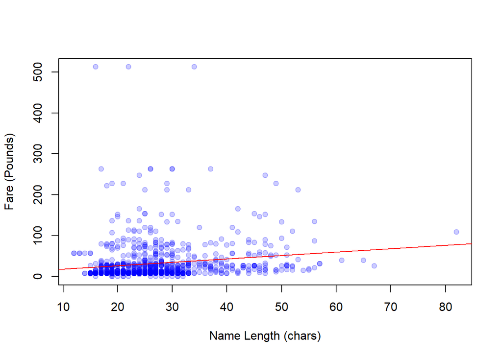

```r
# create NameLength attribute
train$NameLength <- vector("numeric", nrow(train))
for (i in 1:nrow(train)) {
    train$NameLength[i] <- nchar(as.character(train$Name)[i])
}
# see whether NameLength is useful
plot(train$NameLength, train$Fare,
    pch=19, col=rgb(0,0,1,alpha=0.2),
    xlab="Name Length (chars)",
    ylab="Fare (Pounds)")
abline(lm(train$Fare ~ train$NameLength), col="red")
```

While the evidence isn’t particularly strong, we might as well keep `NameLength` in the mix just to see whether it improves modeling later on. Now we could drop `Name`, but will do so after some further cleaning as we use this for EDA later.

## Sex: GenederFac, IsMale

The variable `Sex` is usually best represented as a binary indicator for a given gender in machine learning, however, for plotting purposes we keep a categorical representation, creating `GenderFac` and `IsMale` wherein Male=1.

```r
train$GenderFac <- train$Sex # factor for plotting
train$IsMale <- ifelse(train$Sex=="male",1,0) # indicator for ML
train$Sex <- NULL # drop original
```

# Pre-Processing 3: SibSp, Parch

We conveniently rename `SibSp` and `Parch` to `SiblingSpouse` and `ParentChildren` and create a variable that is a sum of the two: `NumRelatives`.

```r
# Change SibSp and Parch to factor
train$SiblingSpouse <- factor(train$SibSp)
train$ParentChildren <- factor(train$Parch)
train$NumRelatives <- train$SibSp + train$Parch
train$NumRelatives <- factor(train$NumRelatives)
train$SibSp <- NULL
train$Parch <- NULL
```

# Pre-Processing 4: Ticket, Fare

## Ticket

The `Ticket` attribute is somewhat useless as far as extracting information from the ticket number itself. What the ticket number does provide, however, is information on how many tickets were purchased under a given `Fare`, such that we can calculate the **fare per person**, which is what we need since our observational unit (a row) is a person.

Here is a sample of how there are repeated ticket numbers under the same fare:

```r
# EDA into Ticket and Fare
temp_dfm <- train[, colnames(train) %in% c("Name","Ticket","Fare")]
temp_dfm <- temp_dfm[order(temp_dfm["Ticket"]),] # order by Ticket
temp_dfm[1:10,]
```

```
##                                                         Name Ticket  Fare
## 258                                     Cherry, Miss. Gladys 110152 86.50
## 505                                    Maioni, Miss. Roberta 110152 86.50
## 760 Rothes, the Countess. of (Lucy Noel Martha Dyer-Edwards) 110152 86.50
## 263                                        Taussig, Mr. Emil 110413 79.65
## 559                   Taussig, Mrs. Emil (Tillie Mandelbaum) 110413 79.65
## 586                                      Taussig, Miss. Ruth 110413 79.65
## 111                           Porter, Mr. Walter Chamberlain 110465 52.00
## 476                              Clifford, Mr. George Quincy 110465 52.00
## 431                Bjornstrom-Steffansson, Mr. Mauritz Hakan 110564 26.55
## 367         Warren, Mrs. Frank Manley (Anna Sophia Atkinson) 110813 75.25
```

There are many cases of families with the same last name (such as the Taussig above) which leads us to believe that these are not individual prices but group prices under the same ticket. So we keep `Ticket` only to clean fare.

## Fare

We create a `FarePerPerson` attribute and compare it to the `Fare` attribute:

```r
# keep counts of tickets
counts <- aggregate(train$Ticket, by=list(train$Ticket),
                      FUN=function(ticket) sum(!is.na(ticket)))
# function that takes a data frame's fare and ticket counts and apply
divide_fare_count <- function(dfm) {
  fare <- as.numeric(dfm["Fare"])
  # ticket counts
  count_given_ticket <- counts[which(counts[,1] == dfm["Ticket"]), 2]
  result <- round(fare/count_given_ticket,2)
  return(result)
}
# create FarePerPerson
train$FarePerPerson <- apply(X=train, MARGIN=1, FUN=divide_fare_count)

# looking at the temp dataframe of results again
chosen <- c("Name","Ticket","Fare","FarePerPerson")
temp_dfm <- train[, colnames(train) %in% chosen]
temp_dfm <- temp_dfm[order(temp_dfm["Ticket"]),] # order by Ticket
temp_dfm[1:10,]
```

```
##                                                         Name Ticket  Fare
## 258                                     Cherry, Miss. Gladys 110152 86.50
## 505                                    Maioni, Miss. Roberta 110152 86.50
## 760 Rothes, the Countess. of (Lucy Noel Martha Dyer-Edwards) 110152 86.50
## 263                                        Taussig, Mr. Emil 110413 79.65
## 559                   Taussig, Mrs. Emil (Tillie Mandelbaum) 110413 79.65
## 586                                      Taussig, Miss. Ruth 110413 79.65
## 111                           Porter, Mr. Walter Chamberlain 110465 52.00
## 476                              Clifford, Mr. George Quincy 110465 52.00
## 431                Bjornstrom-Steffansson, Mr. Mauritz Hakan 110564 26.55
## 367         Warren, Mrs. Frank Manley (Anna Sophia Atkinson) 110813 75.25
##     FarePerPerson
## 258         28.83
## 505         28.83
## 760         28.83
## 263         26.55
## 559         26.55
## 586         26.55
## 111         26.00
## 476         26.00
## 431         26.55
## 367         75.25
```

We can now drop `Fare`, `Name`, and `Ticket`, but we can keep the ticket counts as its own attribute `TicketCount`:

```r
# create TicketCount
train$TicketCount <- apply(X=train, MARGIN=1,
                          FUN=function(dfm) counts[which(counts[,1] == dfm["Ticket"]), 2])
# drop Fare, Name, and Ticket
'%ni%' <- Negate('%in%')
not_chosen <- c("Fare","Name","Ticket")
train <- train[,colnames(train) %ni% not_chosen]
```

Since `FarePerPerson` has a skewed distribution (as we shall see in the Graphical EDA section) we create a `FarePerPErsonLog` variable which will help with linear models.

```r
# create FareLog
train$FarePerPersonLog <- log(train$FarePerPerson+1)
```

```r
names(train)
```

```
##  [1] "Age"              "Cabin"            "Embarked"
##  [4] "SurvivedFac"      "SurvivedNum"      "PclassFac"
##  [7] "PclassNum"        "Title"            "NameLength"
## [10] "GenderFac"        "IsMale"           "SiblingSpouse"
## [13] "ParentChildren"   "NumRelatives"     "FarePerPerson"
## [16] "TicketCount"      "FarePerPersonLog"
```

# Pre-Processing 5: Cabin, Embarked

## Cabin

`Cabin` has 687 NAs and 147 levels yet cabin locations might be important in determining survivability, since the accident happened late at night when people were mostly in their cabins, and lower-letter cabins were near the deck while higher-letter cabins were near the keel where the ship hit the iceberg.

```r
# Cleaning up Cabin
train$CabinClean <- vector("character", nrow(train))
for (i in 1:nrow(train)) {
  # ID digits and white space
    pattern <- "[0-9]*|\\s"
  # reduce to only first letter given multiple cabins
    train$CabinClean[i] <- substr(gsub(pattern, "", train$Cabin[i]),1,1)
    # bin letters higher than F to the F category
    high_cabins <- toupper(letters[letters >"f"])
    if (train$CabinClean[i] %in% high_cabins) train$CabinClean[i] <- "F"
}
# replace old Cabin
train$Cabin <- factor(train$CabinClean)
train$CabinClean <- NULL
```

```r
summary(train$Cabin)
```

```
##    A    B    C    D    E    F NA's
##   15   47   59   33   32   18  687
```

We now have good representations in all cabins and not too many levels but still a lot of missing values, we’ll deal with those later as needed.

## Embarked

We substitute the letters for port names and impute the two missing cases with the majority class.

```r
train$Embarked <- ifelse(train$Embarked=="C","Cherbourg",
                         ifelse(train$Embarked=="Q","Queensland","Southhampton"))
train$Embarked[is.na(train$Embarked)] <- "Southhampton"
train$Embarked <- factor(train$Embarked) # re-factoring
```

# Pre-Processing 6: Age

## Imputing Missing Values

The `Age` variable had to be considered at the end of pre-processing since we will be doing some pre-modeling (modeling during data pre-processing) to impute missing values and needed other variables to be relatively clean before this pre-modeling stage.

It is helpful to visualize the distribution of ages before and after a certain imputing strategy to see the effect it has on the data. The common practice of imputing with measures of center such as the mean or the median (in our case there wouldn’t be much of a difference as the distribution is approximately normal) distorts the distribution. To show this effectively, the y axes must agree:

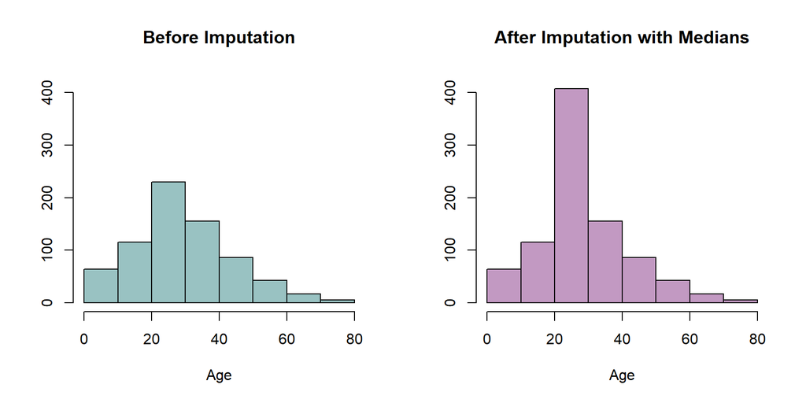

```r
par(mfrow=c(1,2))
hist(train$Age, xlab='Age', main="Before Imputation", ylab="",
     col=rgb(0,0.4,0.4,0.4), ylim=c(0,420))
AgeCopy <- train$Age
AgeCopy[is.na(AgeCopy)] <- median(AgeCopy, na.rm=TRUE)
hist(AgeCopy, xlab='Age', main="After Imputation with Medians", ylab="",
     col=rgb(0.4,0,0.4,0.4), ylim=c(0,420))
```

Imputing medians amounts to deciding that when we do not know an age, we will classify this person as a young adult.

A better strategy would be to **generate random values** given a similar distribution to that which we observed in our traning data, yet one problem with this approach is that it overfits the values we observe, reinforcing patterns that might not necessarily be generalizable.

A final and more sophisticated approach would be to use the rest of the information in the training data and **predict ages** for those individuals, based on other attributes. Since Decision Tree models take missing and unscaled values, and work with categorical features, we can quickly predict ages with minimal modeling.

First we select features for modeling since we have many redundant features (such as the logged variables), and separate the data into sets with age and without age. These features were chosen after a bit of trial and error and plotting of the variable importance score generated by the random forest (see below), which allowed me to simplify the model by removing attributes that weren’t helping the model. In short, the model was too complex and therefore there was too much variance.

```r
# choose features for modeling
chosen <- c("Age","SurvivedFac","PclassFac","Title","NameLength",
            "SiblingSpouse","ParentChildren","FarePerPerson","TicketCount")
yesAge <- train[!is.na(train$Age), colnames(train) %in% chosen] # with ages <- to train and evaluate models
noAge <- train[is.na(train$Age), colnames(train) %in% chosen] # without ages <- to predict
# drop the outcome since it only has missing values
noAge$Age <- NULL
```

Now we can use the dataset with ages to train a tree model:

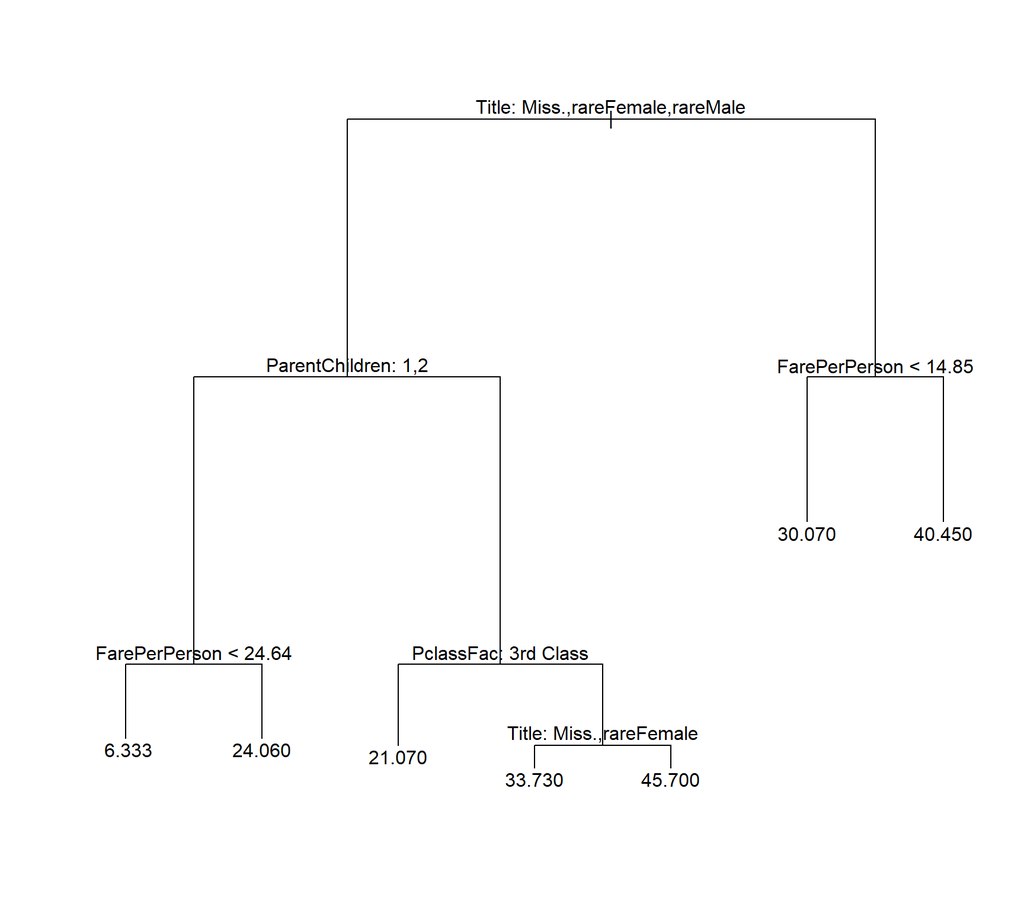

```r
library(tree)
library(caTools)
set.seed(1)
# split on outcome
Y_age <- yesAge[, "Age"]
age_bool <- sample.split(Y_age, SplitRatio = 2/3)
age_train <- yesAge[age_bool, ]
age_test <- yesAge[!age_bool, colnames(yesAge) != "Age"]
# fit model
age_mod <- tree(Age~.,data=age_train)
# plot tree
plot(age_mod)
text(age_mod, pretty=0)
```

One problem with this single tree approach is that another random starting point would generate an entirely different tree. Let’s how this single tree did as far as predicting ages in the test set:

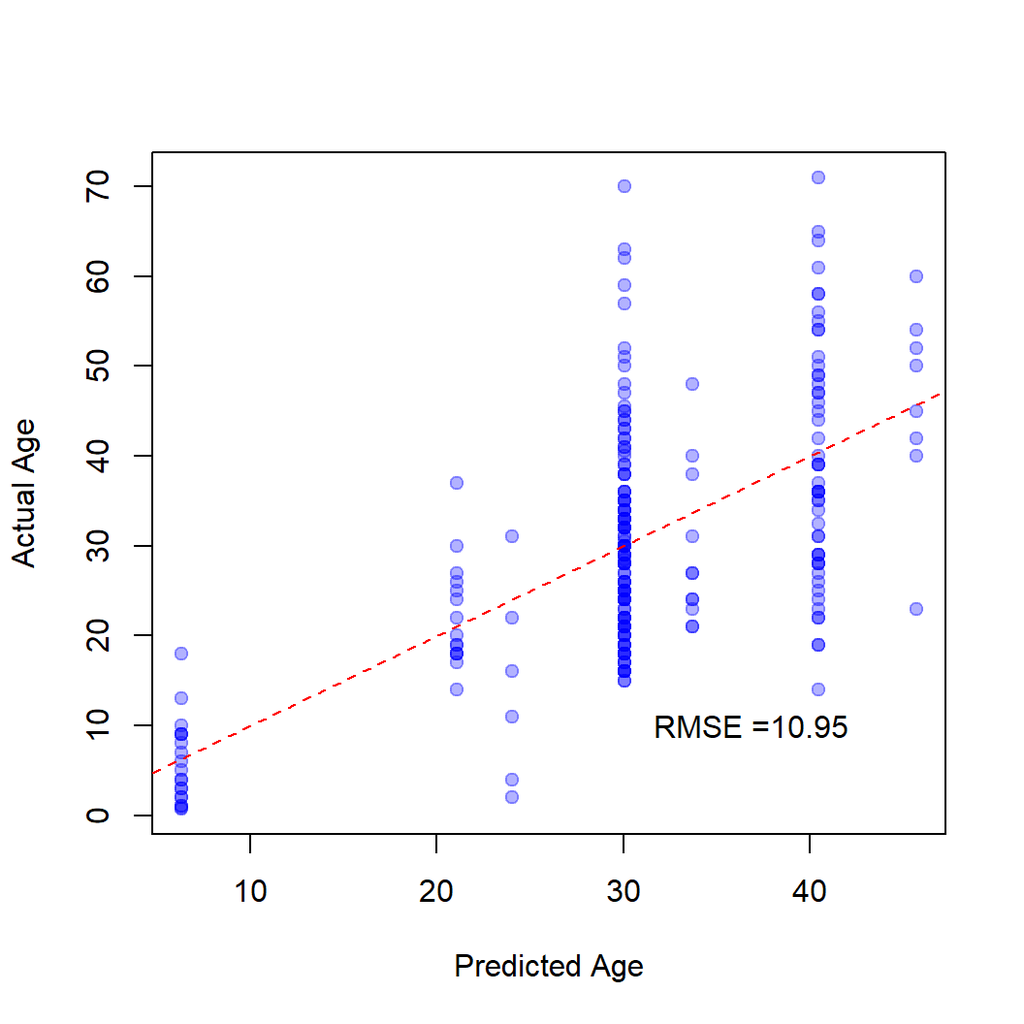

```r
y_hat <- predict(age_mod, newdata=age_test)
y_test <- yesAge[!age_bool, "Age"]
test_RMSE <- round(sqrt(mean((y_hat - y_test)^2)),2)
plot(y_hat, y_test,ylab="Actual Age",xlab="Predicted Age",pch=19,col=rgb(0,0,1,0.3))
text(c(35,40),10, c("RMSE = ", test_RMSE))
abline(0,1, col="red",lty=2)
```

The tree seems to be overpredicting specific ages like 30 and 40 and making lots of errors because of this. Let’s see if an ensemble model like random forest performs better.

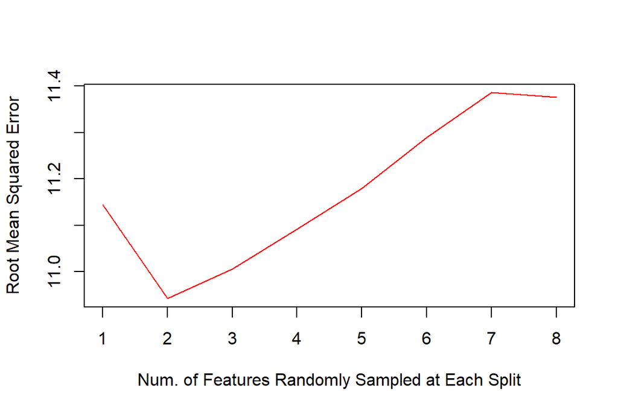

```r
suppressMessages(library(randomForest))
# split on outcome
set.seed(1)
Y_age <- yesAge[, "Age"]
age_bool <- sample.split(Y_age, SplitRatio = 2/3)
age_train <- yesAge[age_bool, ]
age_test <- yesAge[!age_bool, colnames(yesAge) != "Age"]
y_test <- yesAge[!age_bool, "Age"]

# checking various RMSEs
rf_RMSEs <- vector("numeric", length=8)
for (i in 1:8) {
  rf_age <- randomForest(Age ~., data=age_train, mtry=i, na.action=na.omit)
  rf_yhat <- predict(rf_age, newdata=age_test)
  rf_RMSEs[i] <- sqrt(mean((rf_yhat - y_test)^2,na.rm=TRUE))
}
plot(rf_RMSEs, ylim=range(rf_RMSEs), ylab="Root Mean Squared Error", col="red",
     xlab="Num. of Features Randomly Sampled at Each Split", type="l")
```

Looks like the best RMSE is when we use 2 feastures to be randomly sampled at each split.

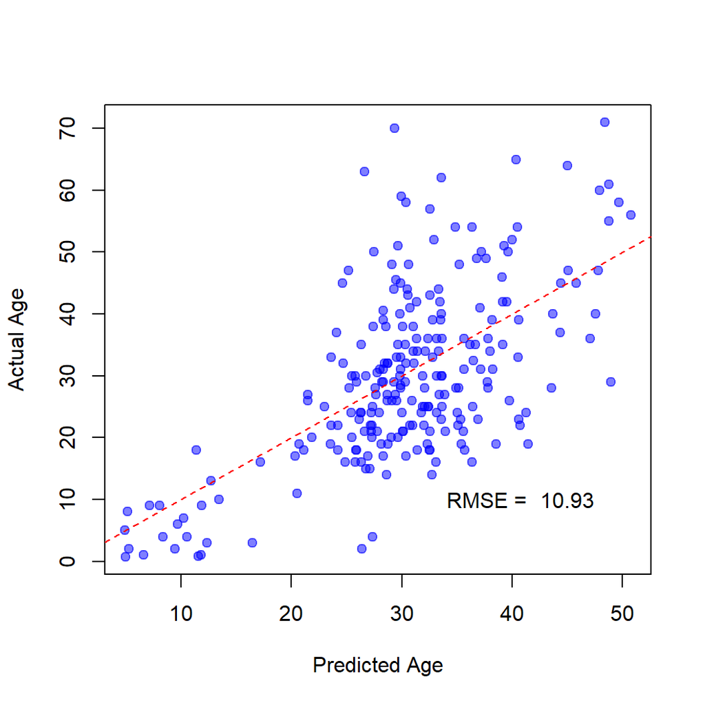

```r
rf_age <- randomForest(Age ~., data=age_train, mtry=2, na.action=na.omit)
rf_yhat <- predict(rf_age, newdata=age_test)
test_RMSE <- round(sqrt(mean((rf_yhat - y_test)^2, na.rm=TRUE)), 2)
plot(rf_yhat, y_test,ylab="Actual Age",xlab="Predicted Age",pch=19,col=rgb(0,0,1,0.5))
text(c(38,45),10, c("RMSE = ", test_RMSE))
abline(0,1, col="red",lty=2)
```

The model seems to make lots of mistakes still but predictions seem more disperse and the RMSE is basically the same.

I believe the random forest model will generalize better than a single tree (we might have gotten lucky with the RMSE) so I make predictions for the `noAge` data with this last ensemble model, imputing values and comparing the new, full `Age` distribution to our original distribution of ages.

For the record, this is how I determined which variables to remove from the overly complex first models I built:

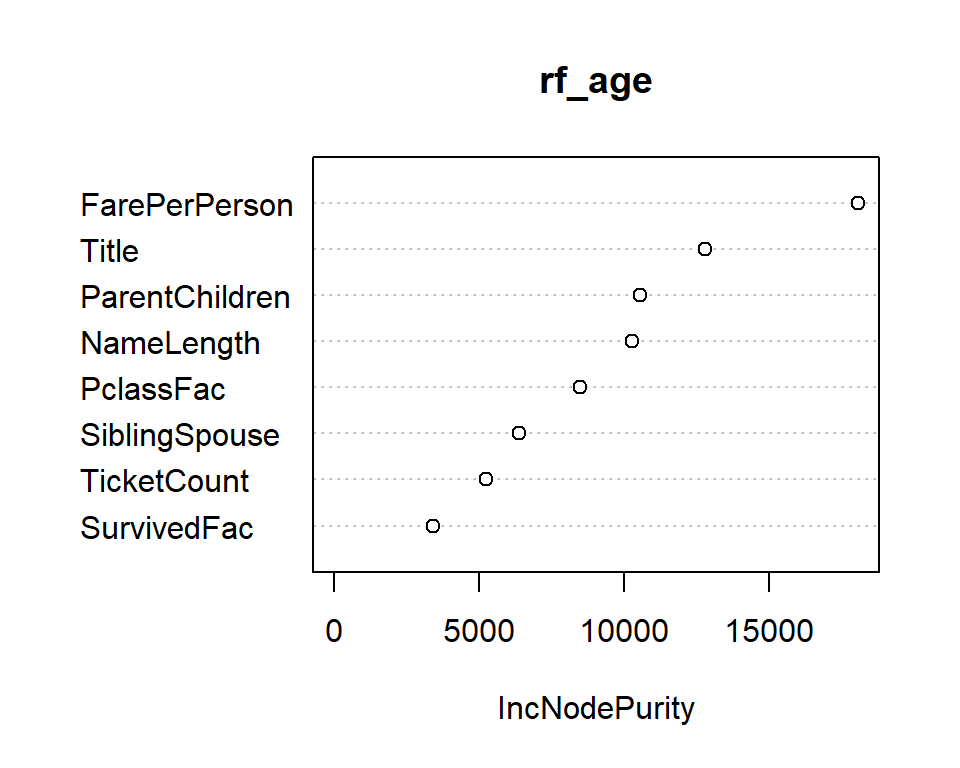

```r
varImpPlot(rf_age)
```

```r
set.seed(1)
rf_age <- randomForest(Age ~., data=yesAge, mtry=2, na.action=na.omit)
# imputing Age predictions
train$Age[is.na(train$Age)] <- round(predict(rf_age, newdata=noAge),0)
sum(is.na(train$Age)) == 0
```

```
## [1] TRUE
```

Confirming we have no missing values in `Age`, we now plot the new distribution of this variable:

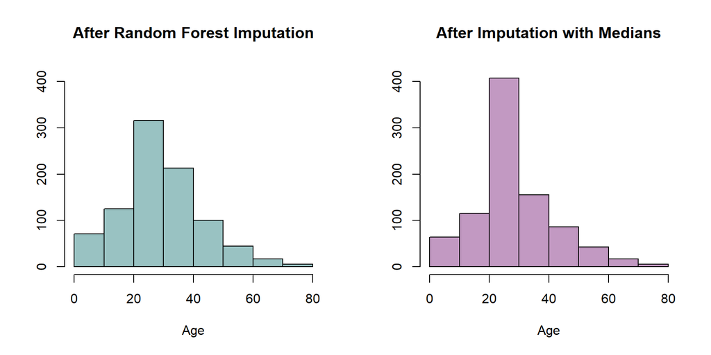

```r
par(mfrow=c(1,2))
hist(train$Age, xlab='Age', main="After Random Forest Imputation", ylab="",
     col=rgb(0,0.4,0.4,0.4), ylim=c(0,420))
hist(AgeCopy, xlab='Age', main="After Imputation with Medians", ylab="",
     col=rgb(0.4,0,0.4,0.4), ylim=c(0,420))
```

We see that the random forest model performed a more sensible imputation than the imputation with medians, as the distribution more closely resembles that of the original `Age` variable.

## Age Categories

We can also create an `AgeFac` variable that bins ages into the following groups: `Child` ($0-12$) `Teen` ($13-19$), `YoungAdult` ($20-35$), `MiddleAged` ($36-55$), and `Elderly` ($56-80$).

```r
# create AgeFac for Age Categories
train$AgeFac <- ifelse(train$Age > 0 & train$Age < 13, "Child",
                    ifelse(train$Age > 12 & train$Age < 20, "Teen",
                    ifelse(train$Age > 19 & train$Age < 36, "YoungAdult",
                    ifelse(train$Age > 35 & train$Age < 56, "MiddleAged", "Elderly"))))
train$AgeFac <- factor(train$AgeFac, levels=c("Child","Teen","YoungAdult","MiddleAged","Elderly"))
train$AgeNum <- as.integer(train$Age)
train$Age <- NULL
```

# Summary After Pre-Processing

First we reorder a bit the variables.

```r
new_order <- c("Cabin","Embarked","PclassNum","PclassFac","NameLength","Title","IsMale",
               "GenderFac","SiblingSpouse","ParentChildren","NumRelatives","TicketCount",
               "FarePerPerson","FarePerPersonLog","AgeNum","AgeFac","SurvivedNum","SurvivedFac")
train <- train[,new_order]
head(train)
```

```
##   Cabin     Embarked PclassNum PclassFac NameLength Title IsMale GenderFac
## 1  <NA> Southhampton         3 3rd Class         23   Mr.      1      male
## 2     C    Cherbourg         1 1st Class         51  Mrs.      0    female
## 3  <NA> Southhampton         3 3rd Class         22 Miss.      0    female
## 4     C Southhampton         1 1st Class         44  Mrs.      0    female
## 5  <NA> Southhampton         3 3rd Class         24   Mr.      1      male
## 6  <NA>   Queensland         3 3rd Class         16   Mr.      1      male
##   SiblingSpouse ParentChildren NumRelatives TicketCount FarePerPerson
## 1             1              0            1           1          7.25
## 2             1              0            1           1         71.28
## 3             0              0            0           1          7.92
## 4             1              0            1           2         26.55
## 5             0              0            0           1          8.05
## 6             0              0            0           1          8.46
##   FarePerPersonLog AgeNum     AgeFac SurvivedNum SurvivedFac
## 1         2.110213     22 YoungAdult           0          no
## 2         4.280547     38 MiddleAged           1         yes
## 3         2.188296     26 YoungAdult           1         yes
## 4         3.316003     35 YoungAdult           1         yes
## 5         2.202765     35 YoungAdult           0          no
## 6         2.247072     30 YoungAdult           0          no
```

```r
# Summary After Pre-Processing
summary(train)
```

```
##   Cabin             Embarked     PclassNum         PclassFac
##  A   : 15   Cherbourg   :168   Min.   :1.000   1st Class:216
##  B   : 47   Queensland  : 77   1st Qu.:2.000   2nd Class:184
##  C   : 59   Southhampton:646   Median :3.000   3rd Class:491
##  D   : 33                      Mean   :2.309
##  E   : 32                      3rd Qu.:3.000
##  F   : 18                      Max.   :3.000
##  NA's:687
##    NameLength           Title         IsMale        GenderFac
##  Min.   :12.00   Miss.     :182   Min.   :0.0000   female:314
##  1st Qu.:20.00   Mr.       :517   1st Qu.:0.0000   male  :577
##  Median :25.00   Mrs.      :125   Median :1.0000
##  Mean   :26.97   rareFemale:  6   Mean   :0.6476
##  3rd Qu.:30.00   rareMale  : 61   3rd Qu.:1.0000
##  Max.   :82.00                    Max.   :1.0000
##
##  SiblingSpouse ParentChildren  NumRelatives  TicketCount
##  0:608         0:678          0      :537   Min.   :1.000
##  1:209         1:118          1      :161   1st Qu.:1.000
##  2: 28         2: 80          2      :102   Median :1.000
##  3: 16         3:  5          3      : 29   Mean   :1.788
##  4: 18         4:  4          5      : 22   3rd Qu.:2.000
##  5:  5         5:  5          4      : 15   Max.   :7.000
##  8:  7         6:  1          (Other): 25
##  FarePerPerson     FarePerPersonLog     AgeNum             AgeFac
##  Min.   :  0.000   Min.   :0.000    Min.   : 0.00   Child     : 76
##  1st Qu.:  7.765   1st Qu.:2.171    1st Qu.:21.00   Teen      :104
##  Median :  8.850   Median :2.287    Median :29.00   YoungAdult:462
##  Mean   : 17.789   Mean   :2.600    Mean   :29.68   MiddleAged:210
##  3rd Qu.: 24.290   3rd Qu.:3.229    3rd Qu.:37.00   Elderly   : 39
##  Max.   :221.780   Max.   :5.406    Max.   :80.00
##
##   SurvivedNum     SurvivedFac
##  Min.   :0.0000   no :549
##  1st Qu.:0.0000   yes:342
##  Median :0.0000
##  Mean   :0.3838
##  3rd Qu.:1.0000
##  Max.   :1.0000
##
```

Class representation in `Cabin` is trouble free although there are a lot of NAs. Class representation in general is not a problem, except perhaps for the rareFemale level in `Title` which we might drop in Part 2 of the project. There are more males than females yet as we shall see, females survived a lot more. The distribution of the number of relative variables is skewed, as well as `FarePerPerson`. A good 38% of the people in the training data survived, so it should not be hard to predict and we do not need to implement SMOTE or other method of balancing classes.

# Univariate Graphical EDA

Now that we have the data in a basic shape for graphical EDA, we can try understanding the underlying distributions and associations of this training set better, remembering that this is just a sample so our findings are not necessarily representative of the population (one hopes that the creators of the Titanic competition in Kaggle used proper random sampling techniques in splitting their train and test samples).

```r
names(train)
```

```
##  [1] "Cabin"            "Embarked"         "PclassNum"
##  [4] "PclassFac"        "NameLength"       "Title"
##  [7] "IsMale"           "GenderFac"        "SiblingSpouse"
## [10] "ParentChildren"   "NumRelatives"     "TicketCount"
## [13] "FarePerPerson"    "FarePerPersonLog" "AgeNum"
## [16] "AgeFac"           "SurvivedNum"      "SurvivedFac"
```

## Cabin, Embarked

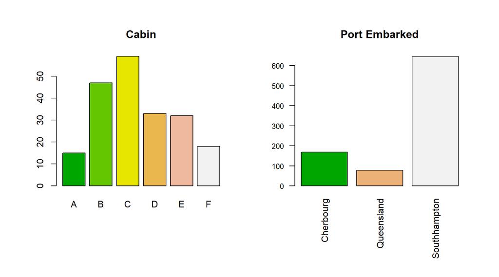

```r
par(mfrow=c(1,2)); par(oma=c(3,1,1,1))
plot(train$Cabin, main="Cabin", col=terrain.colors(6))
plot(train$Embarked, main="Port Embarked", col=terrain.colors(3), cex.axis=0.8, cex.sub=0.8, las=2)
```

Most people were in Cabin C and yet the distribution is not too skewed, while a vast majority embarked in Southhampton.

## PclassFac, NameLength

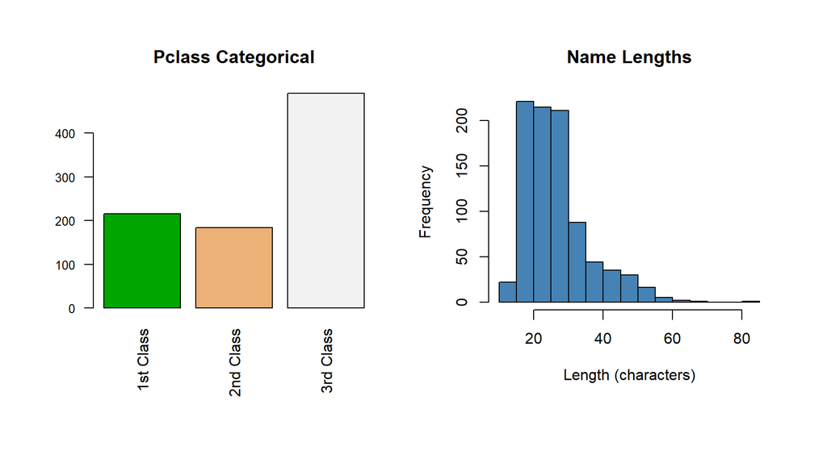

```r
par(mfrow=c(1,2)); par(oma=c(3,1,1,1))
plot(train$PclassFac, main="Pclass Categorical", col=terrain.colors(3),cex.axis=0.8, las=2)
hist(train$NameLength, main="Name Lengths", xlab="Length (characters)", col="steelblue")
```

## Title, GenderFac

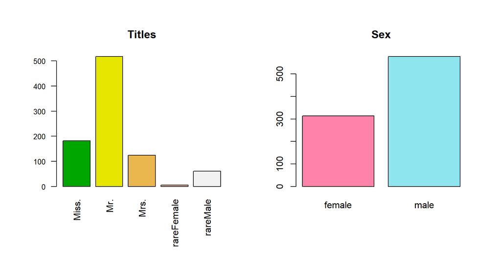

```r
par(mfrow=c(1,2)); par(oma=c(3,1,1,1))
plot(train$Title, main="Titles", col=terrain.colors(5),cex.axis=0.8, las=2)
plot(train$GenderFac, main="Sex", col=c("palevioletred1","cadetblue2"))
```

As noted, rareFemale is under represented. There is a class imbalance in the male and female proportions as well but it is not so sever as to warrant any special treatment.

## SiblingSpouse, ParentChildren

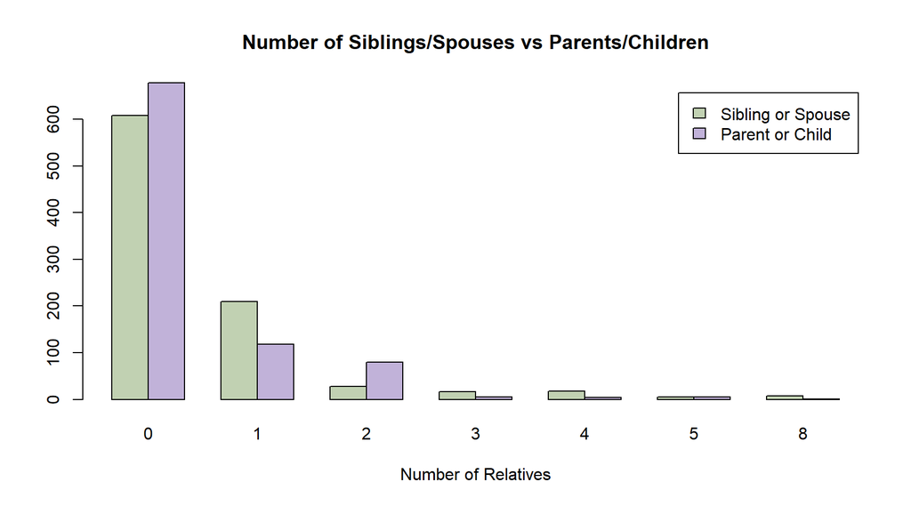

```r
SS <- table(train$SiblingSpouse)
PC <- table(train$ParentChildren)
counts <- rbind(SS,PC)
rownames(counts) <- c("Sibling or Spouse", "Parent or Child")
par(mfrow=c(1,1))
barplot(counts, main="Number of Siblings/Spouses vs Parents/Children",
  xlab="Number of Relatives", ylab="", col=c(rgb(0.2,0.4,0,0.3),rgb(0.2,0,0.5,0.3)),
  legend = rownames(counts), beside=TRUE)
```

The distribution of number of relatives is relatively similar for sibling/spouses and parents/children so combining them makes sense, as seen below.

## NumRelatives, TicketCount

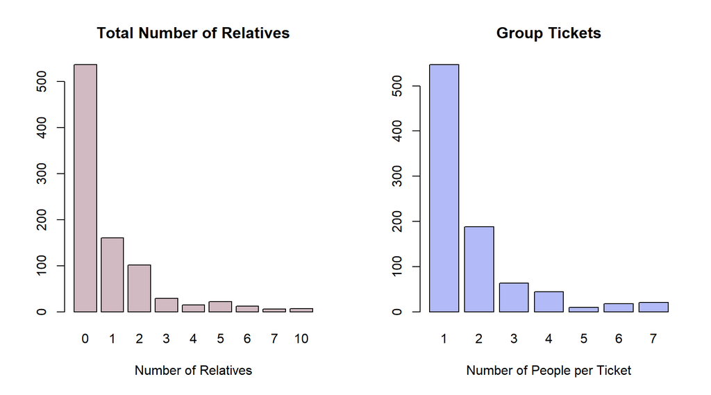

```r
par(mfrow=c(1,2))
barplot(table(train$NumRelatives), main="Total Number of Relatives",
  xlab="Number of Relatives", ylab="", col=rgb(0.4,0.1,0.2,0.3))

barplot(table(train$TicketCount), main="Group Tickets",
  xlab="Number of People per Ticket", ylab="", col=rgb(0,0.1,0.9,0.3))
```

Both `NumRelatives` and `TicketCounts` have skewed distributions, in linear modeling, if these prove to be interesting features, we might still take their log.

## FarePerPerson, FarePerPersonLog

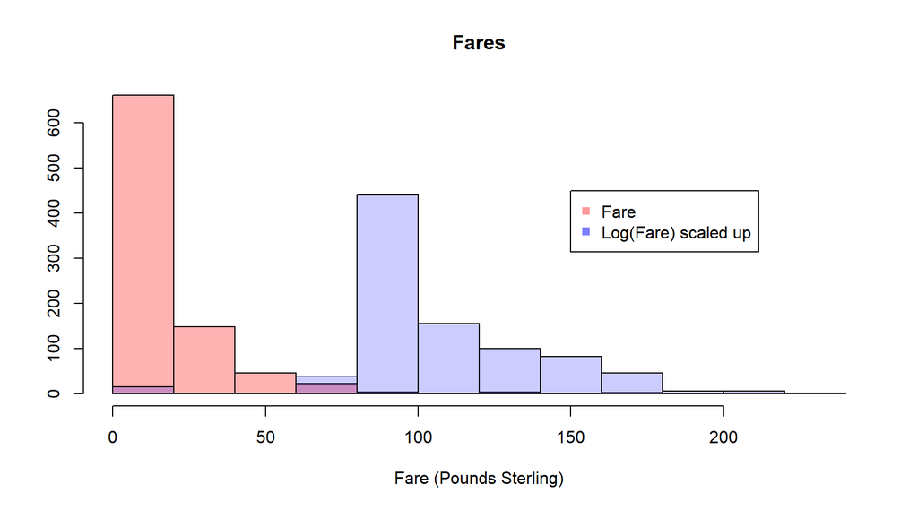

```r
par(mfrow=c(1,1))
hist(train$FarePerPerson, xlab="Fare (Pounds Sterling)", ylab="", main="Fares", col=rgb(1,0,0,0.3))
multiplication_factor <- max(train$FarePerPerson)/max(train$FarePerPersonLog)
hist(train$FarePerPersonLog*multiplication_factor, col=rgb(0,0,1,0.2), ylab="", add=TRUE)
legend(150, 450, pch=15, col=c(rgb(1,0,0,0.4),rgb(0,0,1,0.5)), c("Fare","Log(Fare) scaled up"))
```

The x-axis is shown for the original `Fare` distribution not the logged one, which is scaled up by a multiplication factor which matches the range of the original fare for ease of comparison. As seen, `FarePerPersonLog` is a lot less skewed.

## AgeNum, AgeFac

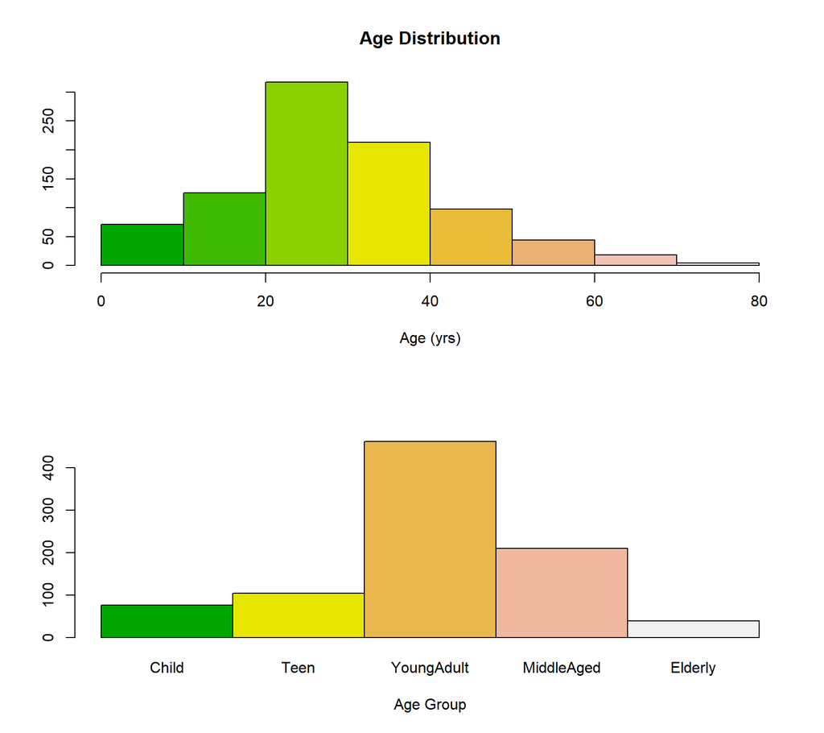

```r
par(mfrow=c(2,1))
hist(train$AgeNum, xlab='Age (yrs)', main="Age Distribution", ylab="", col=terrain.colors(8))
barplot(table(train$AgeFac), xlab='Age Group', ylab="", col=terrain.colors(5), space=c(0,0,0,0,0))
```

Binning the continuous `Age` variable into discrete groups as we did had the effect of centering the distribution, which could be useful depending on our modeling strategy.

## Survived

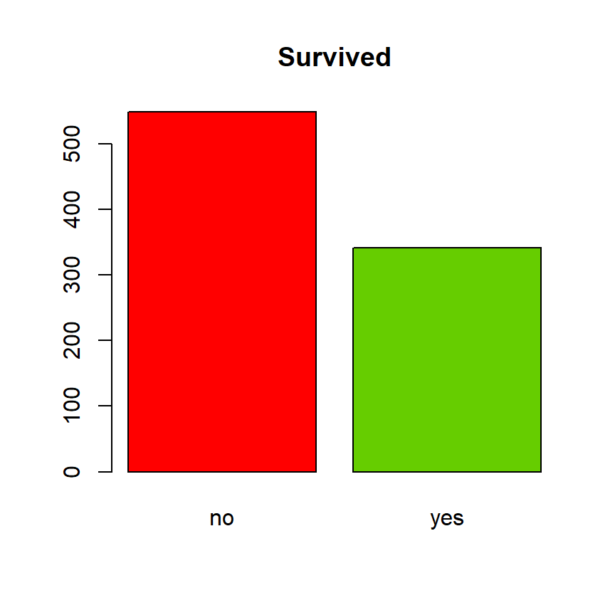

```r
par(mfrow=c(1,1))
# Survived
plot(train$SurvivedFac, main="Survived", col=c("red","chartreuse3"))
```

As noted earlier, the majority did not survive, but class imbalance is not a worry.

# Bivariate Graphical EDA

Our variables are:

```r
names(train)
```

```
##  [1] "Cabin"            "Embarked"         "PclassNum"
##  [4] "PclassFac"        "NameLength"       "Title"
##  [7] "IsMale"           "GenderFac"        "SiblingSpouse"
## [10] "ParentChildren"   "NumRelatives"     "TicketCount"
## [13] "FarePerPerson"    "FarePerPersonLog" "AgeNum"
## [16] "AgeFac"           "SurvivedNum"      "SurvivedFac"
```

There are six redundant features (`PclassFac`,`GenderFac`,`NumRelatives`,`FarePerPersonLog`,`AgeFac`,`SurvivedFac`) if we choose to eliminate `NumRelatives` and not the two variables it captures, which brings us to twelve features.

There are $(n * (n-1)) / 2 = (12 * 11)/2 = 66$ possible bivariate combinations to consider. We can compute bivariate and higher-order combinations with the `combn()` function:

```r
# combinations
head(t(data.frame(combn(12, 2))))
```

```
##    [,1] [,2]
## X1    1    2
## X2    1    3
## X3    1    4
## X4    1    5
## X5    1    6
## X6    1    7
```

```r
tail(t(data.frame(combn(12, 2))))
```

```
##     [,1] [,2]
## X61    9   10
## X62    9   11
## X63    9   12
## X64   10   11
## X65   10   12
## X66   11   12
```

One way to plot several bivariate combinations at once is using a scatterplot matrix. The `plot()` function will do this in R, when passed a **data frame**. Since it is hard to visualize 66 combinations, let’s narrow down to a few choice attributes:

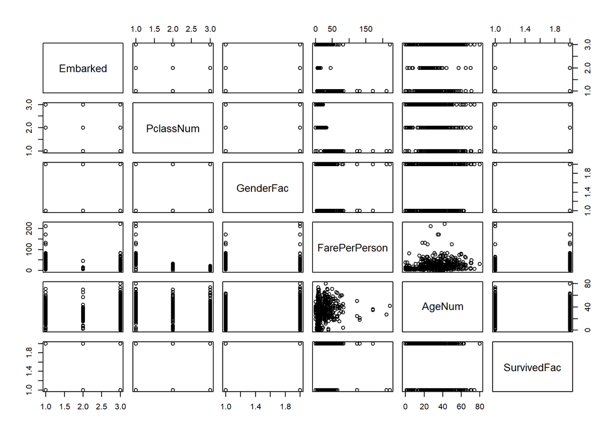

```r
# Scatterplot matrix
chosen <- c("SurvivedFac", "PclassNum", "GenderFac","AgeNum","FarePerPerson","Embarked")
plot(train[,colnames(train) %in% chosen])
```

Numerical attributes like `Age` and `Fare` combine well into a scatterplot, yet other attributes are not plotted exactly as we might want. Since the problem space will only increase with higher-dimensional combinations, we select only a few choice pairs to consider. One approach is to compare each of the other eleven features with our `Survived` outcome.

We can also compute the Pearson product-moment correlation coefficient, which is a measure of the strength of the **linear relationship** (which is why I will refer to it as the **linear correlation coefficient** from now on) between two variables, when we have two numerical variables.

## Bivariate Associations with Survival

### 1 Survived & Cabin

Since our data has so many missing values for cabin, our confidence in the results of this plot should be decreased.

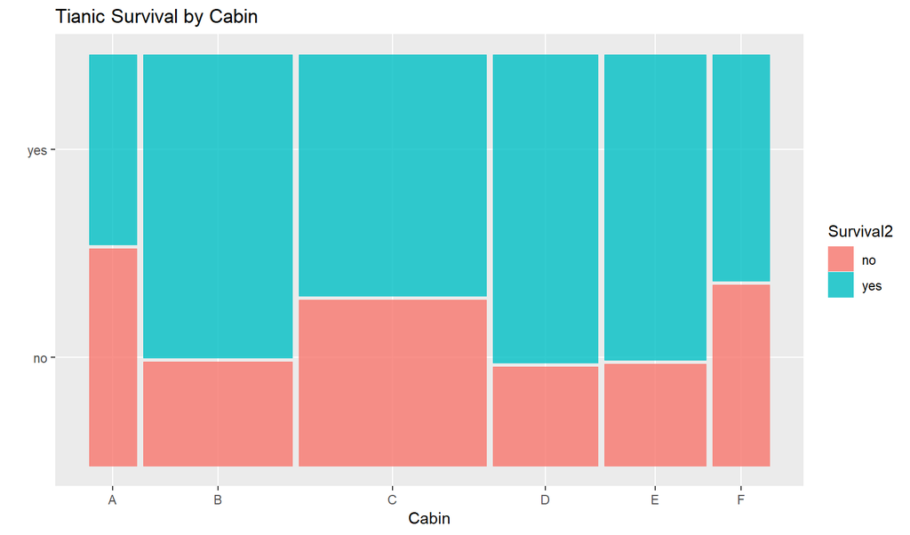

```r
# 1 Survived & Cabin
suppressMessages(library(ggplot2))
suppressMessages(library(ggmosaic))
train2 <- train[!is.na(train$Cabin),] # copy of train w/o NAs
Survival2 <- ifelse(train2$SurvivedNum==1,"yes","no")
ggplot(data=train2) +
   geom_mosaic(aes(x=product(Survival2, Cabin),fill=Survival2)) +
   labs(x='Cabin', y='', title='Tianic Survival by Cabin')
```

It would appear that perhaps cabin is not as associated with survivability as we had hoped for, given that A cabins are on the deck and F cabins near the keel where the ship hit the iceberg.

### 2 Survived & Embarked

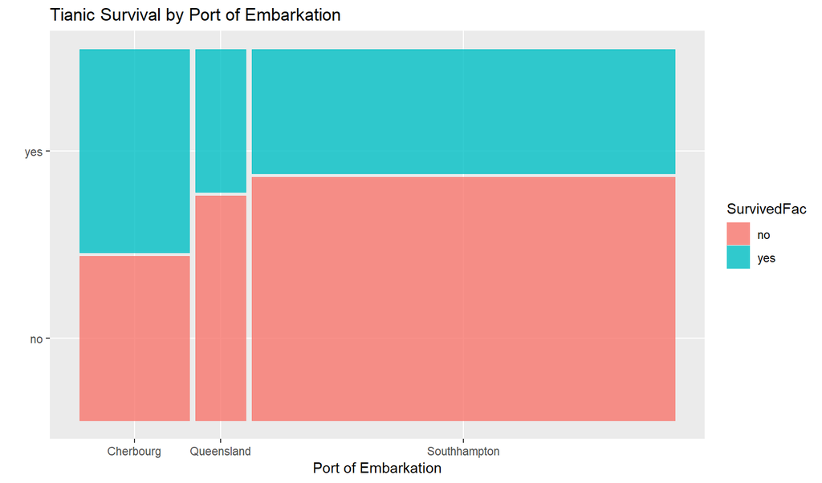

```r
# 2 Survived & Embarked
ggplot(data=train) +
   geom_mosaic(aes(x=product(SurvivedFac, Embarked),fill=SurvivedFac )) +
   labs(x='Port of Embarkation', y='',
   title='Tianic Survival by Port of Embarkation')
```

We can explore port of embarkation in a more nuanced manner by considering the fares paid at each port, and whether survivability appears to me more associated with the fare or the port embarked. We use the log of fares since it would be hard to observe any differences in the boxplots given the highly skewed distribution of fare.

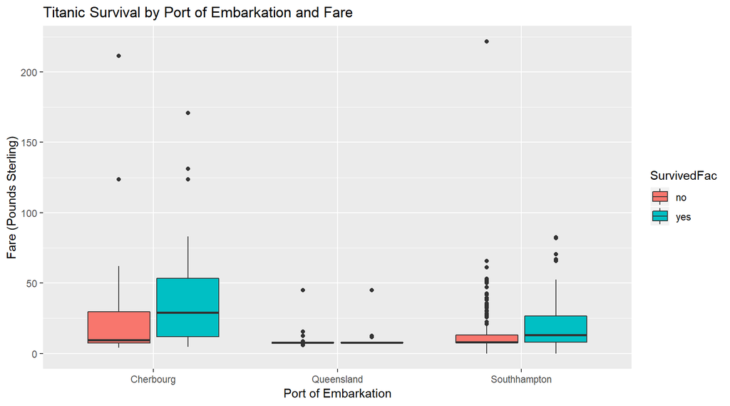

```r
# Survived & Embarked & Fare
ggplot(data=train) +
   geom_boxplot(aes(x=Embarked,y=FarePerPerson, fill=SurvivedFac)) +
   labs(x='Port of Embarkation', y='Fare (Pounds Sterling)',
   title='Titanic Survival by Port of Embarkation and Fare')
```

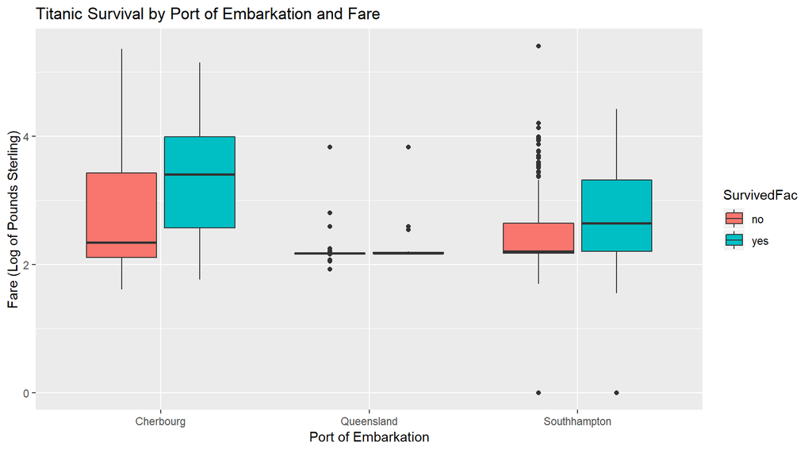

```r
# Survived & Embarked & Fare
ggplot(data=train) +
   geom_boxplot(aes(x=Embarked,y=FarePerPersonLog, fill=SurvivedFac)) +
   labs(x='Port of Embarkation', y='Fare (Log of Pounds Sterling)',
   title='Titanic Survival by Port of Embarkation and Fare')
```

Curiously, the differences between survival and no survival in the Queensland sample are not to be found in fares.

### 3 Survived & Pclass

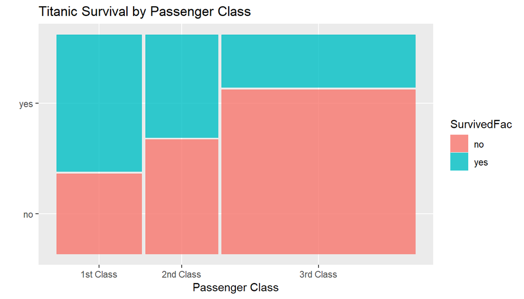

```r
# 3 Survived and Pclass
ggplot(data=train) +
   geom_mosaic(aes(x=product(SurvivedFac, PclassFac),fill=SurvivedFac)) +
   labs(x='Passenger Class', y='', title='Titanic Survival by Passenger Class')
```

Not surprisingly, passenger’s class was taken into account when getting the the life boats, so people in third class took the brunt of it, and first class folks had it best. What the mosaic plot also shows is the proportions of these classes in our sample, which we hope are somewhat generalizable.

The linear correlation coefficient shows this negative association with higher class numbers:

```r
cor(train$SurvivedNum,train$PclassNum)
```

```
## [1] -0.338481
```

### 4 Survived and Name Length

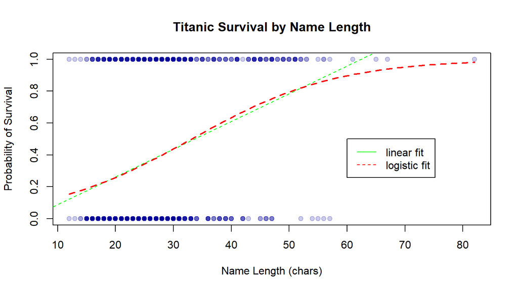

```r
# 4 Survived and NameLength
plot(train$SurvivedNum~train$NameLength, pch=19, col=rgb(0,0,.6,.2),
    main="Titanic Survival by Name Length",
    ylab="Probability of Survival", xlab="Name Length (chars)")
linmod=lm(SurvivedNum~NameLength,data=train)
abline(linmod, col="green", lwd=1, lty=2)
g=glm(SurvivedNum~NameLength,family='binomial',data=train)
curve(predict(g,data.frame(NameLength=x),type="resp"),col="red",lty=2,lwd=2,add=TRUE)
legend(60,0.5,c("linear fit","logistic fit"), col=c("green","red"), lty=c(1,2))
```

Longer names appear to have an association with higher probabilities of survival so we keep this feature. It might just be capturing the association of longer names and wealth, but since in machine learning we do not care about multicollinearity issues, we will test whether to keep this attribute or not during our feature selection modeling phase. The linear fit capture most of the distribution, only failing on a couple outlying cases.

The linear correlation coefficient shows this positive association:

```r
cor(train$SurvivedNum,train$NameLength)
```

```
## [1] 0.3323495
```

### 5 Survived and Title

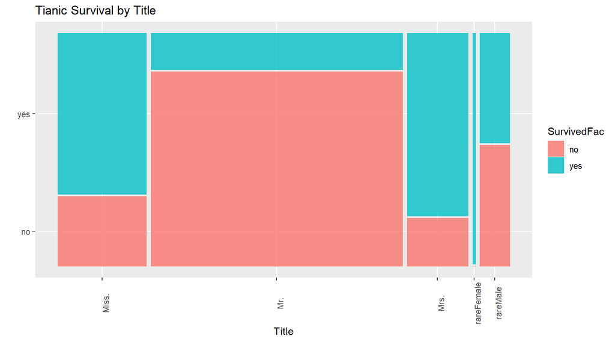

```r
# 5 Survival and Title
ggplot(data=train) +
   geom_mosaic(aes(x=product(SurvivedFac, Title),fill=SurvivedFac)) +
   labs(x='Title', y='',
   title='Tianic Survival by Title') +
   theme(axis.text.x = element_text(angle = 90))
```

Title can be seen as a proxy for gender and as we’ve seen, females survived a lot better than males. It is worth keeping this attribute as it shows some granularity in what kinds of folks survived better within gender groups, i.e. those with rare titles.

### 6 Survived and Gender

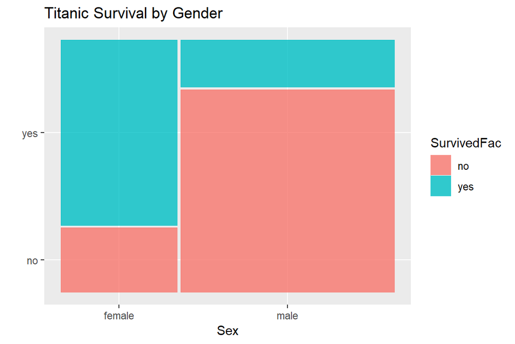

```r
# 6 Survived & Gender
ggplot(data=train) +
   geom_mosaic(aes(x=product(SurvivedFac, GenderFac),fill=SurvivedFac)) +
   labs(x='Sex', y='', title='Titanic Survival by Gender')
```

Females were much more likely to survive, and most of the passengers were male. The linear correlation coefficient shows this tendency (negative correlation for males):

```r
cor(train$SurvivedNum,train$IsMale)
```

```
## [1] -0.5433514
```

### 7 Survived and Sibling/Spouse

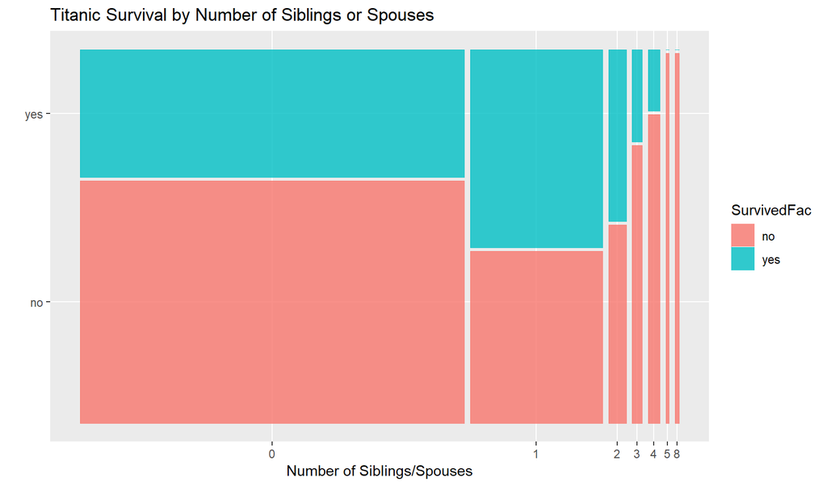

```r
# 7 Survived and Sibling/Spouse
ggplot(data=train) +
   geom_mosaic(aes(x=product(SurvivedFac, SiblingSpouse),fill=SurvivedFac)) +
   labs(x='Number of Siblings/Spouses', y='',
   title='Titanic Survival by Number of Siblings or Spouses')
```

### 8 Survived and Parent/Children

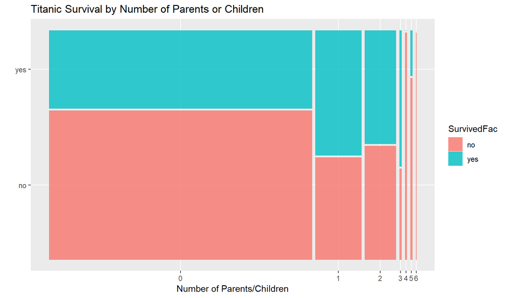

```r
# 8 Survived and Parent/Children
ggplot(data=train) +
   geom_mosaic(aes(x=product(SurvivedFac, ParentChildren),fill=SurvivedFac)) +
   labs(x='Number of Parents/Children', y='',
   title='Titanic Survival by Number of Parents or Children')
```

Similar results to those observed in the previous plot are seen, except for the higher probability of survival for someone with 3 (presumably) children, yet again, since the sample sizes are small, we should not take this finding too seriously.

Let’s look at survival with the composite “Number of Relatives” attribute:

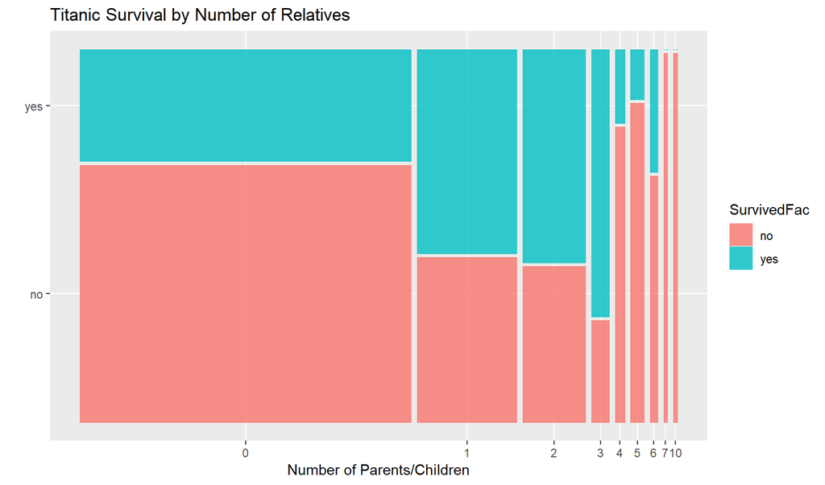

```r
# Survived and Number of Relatives
ggplot(data=train) +
   geom_mosaic(aes(x=product(SurvivedFac, NumRelatives),fill=SurvivedFac)) +
   labs(x='Number of Parents/Children', y='',
   title='Titanic Survival by Number of Relatives')
```

It would seem as though survivability increases from 0 to 3 relatives then suddenly besomes worse, a curious and possibly suspect insight we might consider during **feature engineering** for machine learning.

Because the relationship seems to be nonlinear, the linear correlation coefficient is small:

```r
cor(train$SurvivedNum,as.numeric(train$NumRelatives))
```

```
## [1] 0.02561624
```

### 9 Survived and Ticket Counts

Before plotting, a hypothesis could be formed that higher groups would have higher survival rates, since people could band together, yet one hole in this hypothesis is that perhaps it is unlikely that men would survive more in groups.

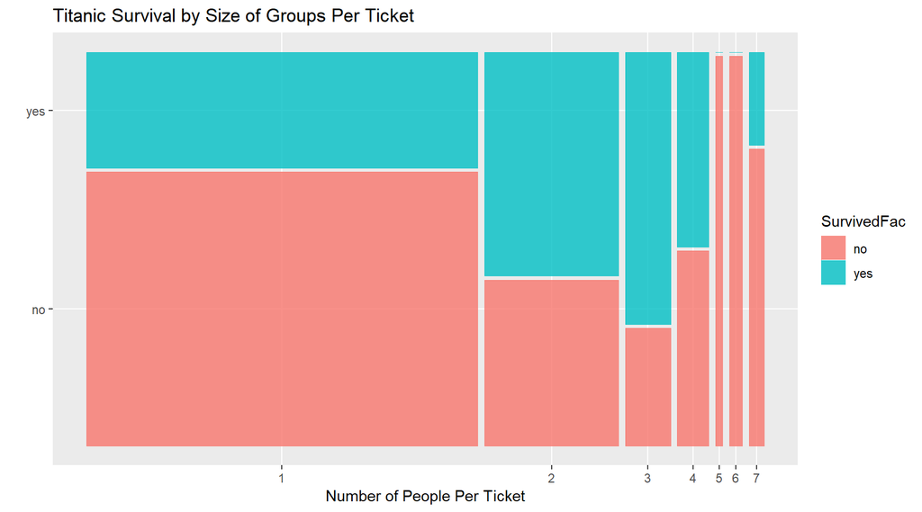

```r
# 9 Survived and Ticket Counts
ticketcounts <- factor(train$TicketCount)
ggplot(data=train) +
   geom_mosaic(aes(x=product(SurvivedFac, ticketcounts),fill=SurvivedFac)) +
   labs(x='Number of People Per Ticket', y='',
   title='Titanic Survival by Size of Groups Per Ticket')
```

The plot shows how how groups of 3 survived best, followed by 2, 4, 1, and other groups are perhaps too unrepresented for a solid interpretation. It is worth exploring in multivariate EDA whether men survived more in groups or alone, or children, and of what classes.

The relationship between survival and groups of people that bought the same ticket appears to be nonlinear, which is why the linear correlation coefficient has a low value.

```r
cor(train$SurvivedNum,train$TicketCount)
```

```
## [1] 0.03824725
```

### 10 Survived and Fare Per Person

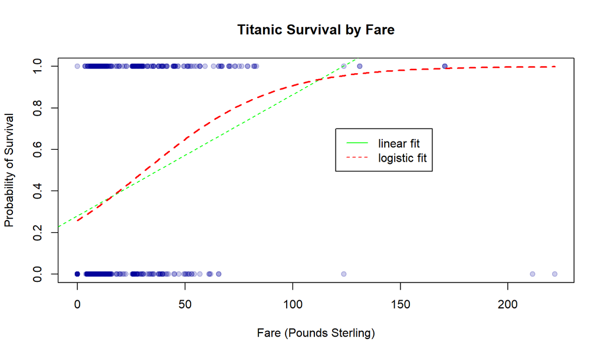

```r
# 10 Survived & Fare
plot(train$SurvivedNum~train$FarePerPerson, pch=19, col=rgb(0,0,.6,.2),
    main="Titanic Survival by Fare",ylab="Probability of Survival", xlab="Fare (Pounds Sterling)")
linmod=lm(SurvivedNum~FarePerPerson,data=train)
abline(linmod, col="green", lwd=1, lty=2)
g=glm(SurvivedNum~FarePerPerson,family='binomial',data=train)
curve(predict(g,data.frame(FarePerPerson=x),type="resp"),col="red",lty=2,lwd=2,add=TRUE)
legend(120,0.7,c("linear fit","logistic fit"), col=c("green","red"), lty=c(1,2))
```

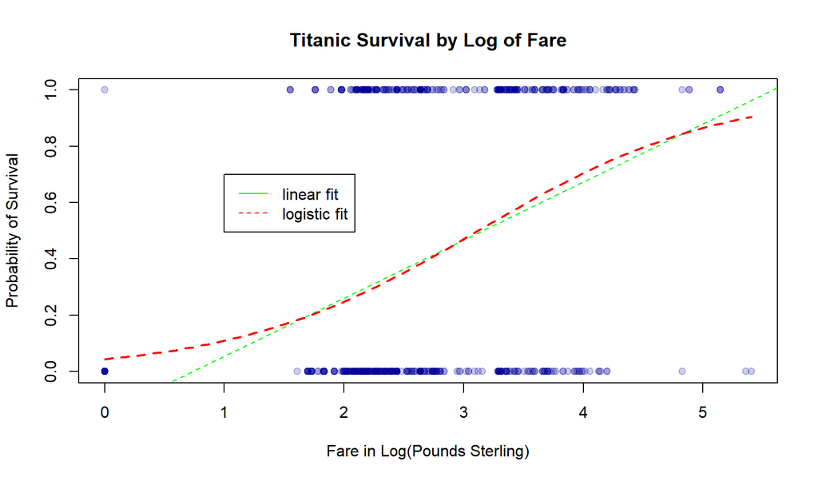

```r
# 10 Survived & Log(Fare)
plot(train$SurvivedNum~train$FarePerPersonLog, pch=19, col=rgb(0,0,.6,.2),
    main="Titanic Survival by Log of Fare",
    ylab="Probability of Survival", xlab="Fare in Log(Pounds Sterling)")
linmod=lm(SurvivedNum~FarePerPersonLog,data=train)
abline(linmod, col="green", lwd=1, lty=2)
g=glm(SurvivedNum~FarePerPersonLog,family='binomial',data=train)
curve(predict(g,data.frame(FarePerPersonLog=x),type="resp"),col="red",lty=2,lwd=2,add=TRUE)
legend(1,0.7,c("linear fit","logistic fit"), col=c("green","red"), lty=c(1,2))
```

By computing the linear correlation coefficient for both variables, we see an improvement in the strength of the linear relationship when we use the logged version of fare:

```r
cor(train$SurvivedNum,train$FarePerPerson)
```

```
## [1] 0.2548164
```

```r
cor(train$SurvivedNum,train$FarePerPersonLog)
```

```
## [1] 0.3243129
```